# 19_cents

## 19_cents

#### Question

1. In music, to compare two frequencies (to measure an interval), we can use cents.

   $$I = 1200 \cdot \log_2 \left(\frac{f_2}{f_1}\right)$$

   where $I$ is the size of the interval in cents, $f_1$ is the first frequency (typically in hertz), and $f_2$ is the second frequency.

   A pianist plays $A_{2}$ and $D_{3}$. On a [standard 88-key piano](https://en.wikipedia.org/wiki/Piano_key_frequencies), these notes correspond to key number $k_1=25$ and $k_2=30$, and their frequencies are $f_1\approx 110$ Hz and $f_2\approx 146.832384$ Hz.

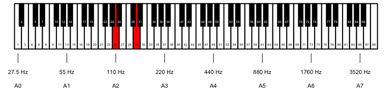

   Find $I$, the size of the interval in cents.

#### Question

2. In music, to compare two frequencies (to measure an interval), we can use cents.

   $$I = 1200 \cdot \log_2 \left(\frac{f_2}{f_1}\right)$$

   where $I$ is the size of the interval in cents, $f_1$ is the first frequency (typically in hertz), and $f_2$ is the second frequency.

   A pianist plays $E_{6}$ and $A_{6}$. On a [standard 88-key piano](https://en.wikipedia.org/wiki/Piano_key_frequencies), these notes correspond to key number $k_1=68$ and $k_2=73$, and their frequencies are $f_1\approx 1318.5102277$ Hz and $f_2\approx 1760$ Hz.

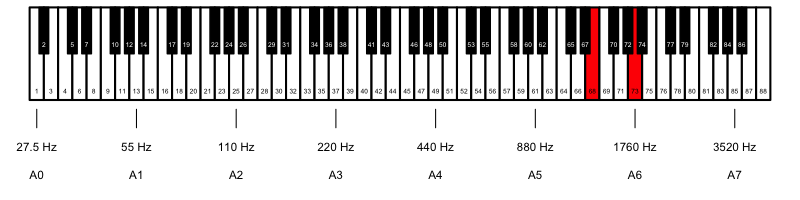

   Find $I$, the size of the interval in cents.

#### Question

3. In music, to compare two frequencies (to measure an interval), we can use cents.

   $$I = 1200 \cdot \log_2 \left(\frac{f_2}{f_1}\right)$$

   where $I$ is the size of the interval in cents, $f_1$ is the first frequency (typically in hertz), and $f_2$ is the second frequency.

   A pianist plays $C_{1}$ and $G^{\#}_{1}$. On a [standard 88-key piano](https://en.wikipedia.org/wiki/Piano_key_frequencies), these notes correspond to key number $k_1=4$ and $k_2=12$, and their frequencies are $f_1\approx 32.7031957$ Hz and $f_2\approx 51.9130872$ Hz.

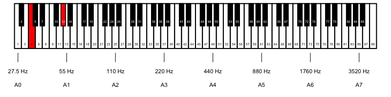

   Find $I$, the size of the interval in cents.

#### Question

4. In music, to compare two frequencies (to measure an interval), we can use cents.

   $$I = 1200 \cdot \log_2 \left(\frac{f_2}{f_1}\right)$$

   where $I$ is the size of the interval in cents, $f_1$ is the first frequency (typically in hertz), and $f_2$ is the second frequency.

   A pianist plays $E_{3}$ and $F^{\#}_{3}$. On a [standard 88-key piano](https://en.wikipedia.org/wiki/Piano_key_frequencies), these notes correspond to key number $k_1=32$ and $k_2=34$, and their frequencies are $f_1\approx 164.8137785$ Hz and $f_2\approx 184.9972114$ Hz.

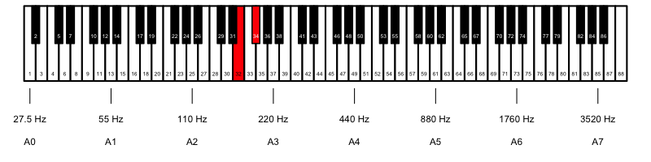

   Find $I$, the size of the interval in cents.

#### Question

5. In music, to compare two frequencies (to measure an interval), we can use cents.

   $$I = 1200 \cdot \log_2 \left(\frac{f_2}{f_1}\right)$$

   where $I$ is the size of the interval in cents, $f_1$ is the first frequency (typically in hertz), and $f_2$ is the second frequency.

   A pianist plays $C_{2}$ and $A_{5}$. On a [standard 88-key piano](https://en.wikipedia.org/wiki/Piano_key_frequencies), these notes correspond to key number $k_1=16$ and $k_2=61$, and their frequencies are $f_1\approx 65.4063913$ Hz and $f_2\approx 880$ Hz.

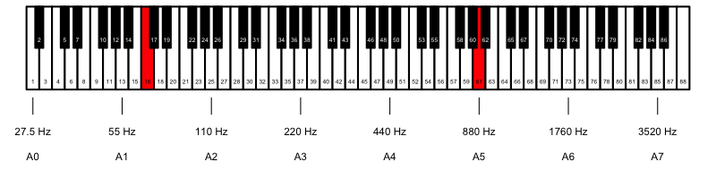

   Find $I$, the size of the interval in cents.

#### Question

6. In music, to compare two frequencies (to measure an interval), we can use cents.

   $$I = 1200 \cdot \log_2 \left(\frac{f_2}{f_1}\right)$$

   where $I$ is the size of the interval in cents, $f_1$ is the first frequency (typically in hertz), and $f_2$ is the second frequency.

   A pianist plays $D_{6}$ and $C^{\#}_{7}$. On a [standard 88-key piano](https://en.wikipedia.org/wiki/Piano_key_frequencies), these notes correspond to key number $k_1=66$ and $k_2=77$, and their frequencies are $f_1\approx 1174.6590717$ Hz and $f_2\approx 2217.4610478$ Hz.

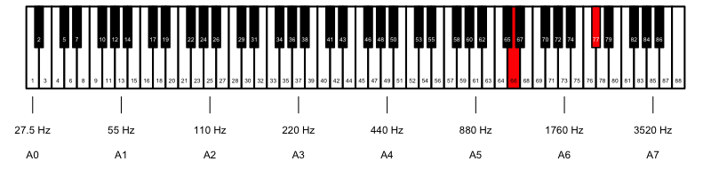

   Find $I$, the size of the interval in cents.

#### Question

7. In music, to compare two frequencies (to measure an interval), we can use cents.

   $$I = 1200 \cdot \log_2 \left(\frac{f_2}{f_1}\right)$$

   where $I$ is the size of the interval in cents, $f_1$ is the first frequency (typically in hertz), and $f_2$ is the second frequency.

   A pianist plays $D^{\#}_{6}$ and $F^{\#}_{6}$. On a [standard 88-key piano](https://en.wikipedia.org/wiki/Piano_key_frequencies), these notes correspond to key number $k_1=67$ and $k_2=70$, and their frequencies are $f_1\approx 1244.5079349$ Hz and $f_2\approx 1479.9776908$ Hz.

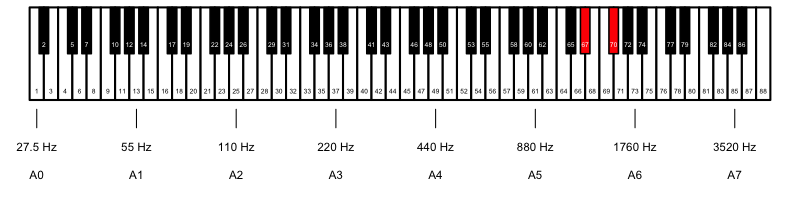

   Find $I$, the size of the interval in cents.

#### Question

8. In music, to compare two frequencies (to measure an interval), we can use cents.

   $$I = 1200 \cdot \log_2 \left(\frac{f_2}{f_1}\right)$$

   where $I$ is the size of the interval in cents, $f_1$ is the first frequency (typically in hertz), and $f_2$ is the second frequency.

   A pianist plays $D_{1}$ and $F^{\#}_{7}$. On a [standard 88-key piano](https://en.wikipedia.org/wiki/Piano_key_frequencies), these notes correspond to key number $k_1=6$ and $k_2=82$, and their frequencies are $f_1\approx 36.708096$ Hz and $f_2\approx 2959.9553817$ Hz.

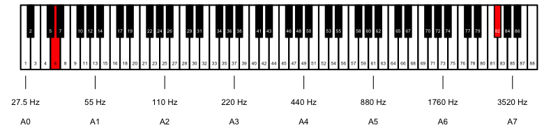

   Find $I$, the size of the interval in cents.